# Correlation and OLS Regression

## Introduction

In this R Markdown, we will cover the R code for correlation and OLS regression analysis. This markdown is meant to serve as a companion to the lecture slides, and doesn’t go into detail when interpreting the output.

```r
library(Hmisc)
library(DAAG)
library(car)  #to calculate VIF
library(MASS)
library(rsq)
library(tidyverse)
library(caret)
library(dplyr)
```

## Correlations

```r
setwd("C:/Users/eugeneby/Dropbox/Documents/Work and School/Teaching/CPLN 671 - Statistics and Data Mining/Data/Lecture 3 - R")
mydata <- read.csv("Pearson_Spearman_Correlations.csv")
options(scipen = 999)
```

Let’s view the first few rows of the data and look at summary statistics of each variable.

```r
head(mydata)
```

```
##   X          Y RankX RankY
## 1 1   2.718282     1     1
## 2 2   7.389056     2     2
## 3 3  20.085537     3     3
## 4 4  54.598150     4     4
## 5 5 148.413159     5     5
## 6 6 403.428793     6     6
```

```r
summary(mydata)
```

```
##        X                Y
##  Min.   :  1.00   Min.   :                                           3
##  1st Qu.: 25.75   1st Qu.:                                164798724834
##  Median : 50.50   Median :                      9639104999999999574466
##  Mean   : 50.50   Mean   :  425254099764000012506226246444000824464282
##  3rd Qu.: 75.25   3rd Qu.:           533693000000000009440804040866446
##  Max.   :100.00   Max.   :26881199999999999944084468048668244866662808
##      RankX            RankY
##  Min.   :  1.00   Min.   :  1.00
##  1st Qu.: 25.75   1st Qu.: 25.75
##  Median : 50.50   Median : 50.50
##  Mean   : 50.50   Mean   : 50.50
##  3rd Qu.: 75.25   3rd Qu.: 75.25
##  Max.   :100.00   Max.   :100.00
```

We can also create a scatter plot between variables `X` and `Y` in data frame `mydata`. The exponential relationship between the two variables is evident in the scatter plot.

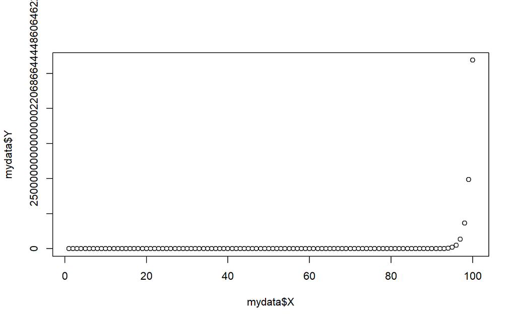

```r
plot(mydata$X, mydata$Y)
```

Now, let’s look at the Pearson and Spearman correlation between variables `X` and `Y` in data frame `mydata`.

```r
cor(mydata$X, mydata$Y, method="pearson")       #method can be pearson or spearman
```

```
## [1] 0.2520319
```

```r
cor(mydata$X, mydata$Y, method="spearman")
```

```
## [1] 1
```

In the results above, note that the Perason and Spearman correlations are substantially different. Becase the variables were defined such that the relationship between `X` and `Y` is not linear but exponential, it’s not surprising that the Pearson correlation coefficient, which measures the strength of the linear association, is relatively small. However, recall that Spearman correlation is simply the Pearson correlation coefficient of the ranks, and because `Y` always goes up as `X` goes up, the Spearman correlation coefficient here is 1. Said differently, looking at the Spearman correlation between `X` and `Y` is the same as looking at the Pearson correlation between `RankX` and `RankY`.

```r
cor(mydata$RankX, mydata$RankY, method="pearson")
```

```
## [1] 1
```

We can also look at the correlation matrix for all variables in the data set `mydata`

```r
cor(mydata)
```

```
##               X         Y     RankX     RankY
## X     1.0000000 0.2520319 1.0000000 1.0000000
## Y     0.2520319 1.0000000 0.2520319 0.2520319
## RankX 1.0000000 0.2520319 1.0000000 1.0000000
## RankY 1.0000000 0.2520319 1.0000000 1.0000000
```

We can also use R to run hypothesis tests - that is, examine whether the Pearson correlation between `X` and `Y` is significant. In the example below, the p-value is 0.01142 - since it’s significantly lower than 0.05, we reject the null hypothesis that the population correlation coefficient ρ = 0.

```r
cor.test(mydata$X, mydata$Y, method=("pearson"))
```

```
##
##  Pearson's product-moment correlation
##
## data:  mydata$X and mydata$Y
## t = 2.5782, df = 98, p-value = 0.01142
## alternative hypothesis: true correlation is not equal to 0
## 95 percent confidence interval:
##  0.0585103 0.4272973
## sample estimates:
##       cor
## 0.2520319
```

The p-value for the Spearman correlation coefficient is infinitesimally small, so we can definitely reject H0 that ρ = 0.

```r
cor.test(mydata$X, mydata$Y, method=("spearman"))
```

```
##
##  Spearman's rank correlation rho
##
## data:  mydata$X and mydata$Y
## S = 0, p-value < 0.00000000000000022
## alternative hypothesis: true rho is not equal to 0
## sample estimates:
## rho
##   1
```

Note that the `cor.test` command can only be applied to a pair of variables, and not to a data frame. While the `cor(mydata)` command presents a correlation matrix, the command `cor.test(mydata)` yields an error.

However, sometimes it’s really convenient to get p-values as a matrix, and the `Hmisc` package allows us to do that. We can do this for both Pearson and Spearman correlations.

```r
pearson <- rcorr(as.matrix(mydata), type="pearson")
pearson$r                    # correlation matrix (r's)
```

```
##               X         Y     RankX     RankY
## X     1.0000000 0.2520319 1.0000000 1.0000000
## Y     0.2520319 1.0000000 0.2520319 0.2520319
## RankX 1.0000000 0.2520319 1.0000000 1.0000000
## RankY 1.0000000 0.2520319 1.0000000 1.0000000
```

```r
pearson$P                    # p-values for the correlation matrix
```

```
##              X        Y    RankX    RankY
## X           NA 0.011419 0.000000 0.000000
## Y     0.011419       NA 0.011419 0.011419
## RankX 0.000000 0.011419       NA 0.000000
## RankY 0.000000 0.011419 0.000000       NA
```

In this example, note that the p-values for the Spearman correlations are rounded down to 0, however a p-value is never exactly 0. When reporting the p-value we can simply write that it’s <0.0001.

```r
spearman <- rcorr(as.matrix(mydata), type="spearman")
spearman$r                    # correlation matrix (r's)
```

```
##       X Y RankX RankY
## X     1 1     1     1
## Y     1 1     1     1
## RankX 1 1     1     1
## RankY 1 1     1     1
```

```r
spearman$P                    # p-values for the correlation matrix
```

```
##        X  Y RankX RankY
## X     NA  0     0     0
## Y      0 NA     0     0
## RankX  0  0    NA     0
## RankY  0  0     0    NA
```

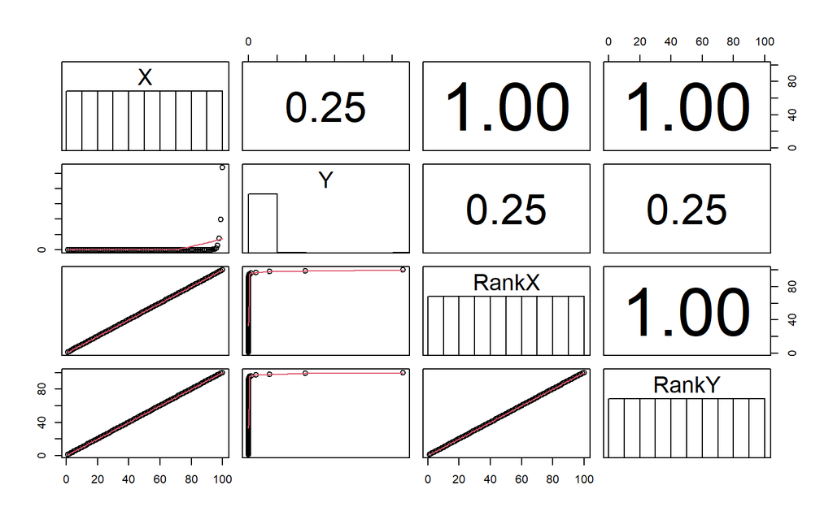

```r
#Setting up the function to show correlations such that higher correlations are in a larger font
panel.cor <- function(x, y, digits = 2, prefix = "", cex.cor, ...) {
  usr <- par("usr")
  on.exit(par(usr))
  par(usr = c(0, 1, 0, 1))
  r <- abs(cor(x, y, use = "complete.obs"))
  txt <- format(c(r, 0.123456789), digits = digits)[1]
  txt <- paste(prefix, txt, sep = "")
  if (missing(cex.cor)) cex.cor <- 0.8/strwidth(txt)
  text(0.5, 0.5, txt, cex =  cex.cor * (1 + r) / 2)
}

#Setting up the function to show histograms on the main diagonal
panel.hist <- function(x, ...) {
  usr <- par("usr")
  on.exit(par(usr))
  par(usr = c(usr[1:2], 0, 1.5) )
  h <- hist(x, plot = FALSE)
  breaks <- h$breaks
  nB <- length(breaks)
  y <- h$counts
  y <- y/max(y)
  rect(breaks[-nB], 0, breaks[-1], y, col = "white", ...)
}

#Here we go!
pairs(
  mydata,
  upper.panel = panel.cor,
  diag.panel  = panel.hist,
  lower.panel = panel.smooth
)
```

## Simple Regression

Now, let’s move on to simple OLS regression - that is, regression with one predictor. Here, we are importing the data set that we used in class, which looks at the relationship between age of kids and their vocabulary (i.e., how many words they know). Let’s import the data and look at the first few rows.

```r
setwd("C:\\Users\\eugeneby\\Dropbox\\Documents\\Work and School\\Teaching\\CPLN 671 - Statistics and Data Mining\\2023_MUSA_5000_GitHub\\Data\\Lecture 4 and 5 - R")
simpleregdata <- read.csv("Age - Vocabulary Example.csv")
head(simpleregdata)
```

```
##   Person.. ChildAge Vocabulary
## 1        1        8       2800
## 2        2        3        800
## 3        3        4       1200
## 4        4        5       1700
## 5        5        6       1600
## 6        6        6       1800
```

Now, let’s look at summary statistics of each variable. We see that the average age of the kids in our data set is 5, and the average vocabulary is 1530 words.

```r
summary(simpleregdata)
```

```
##     Person..        ChildAge   Vocabulary
##  Min.   : 1.00   Min.   :2   Min.   : 300
##  1st Qu.: 3.25   1st Qu.:4   1st Qu.:1225
##  Median : 5.50   Median :5   Median :1600
##  Mean   : 5.50   Mean   :5   Mean   :1530
##  3rd Qu.: 7.75   3rd Qu.:6   3rd Qu.:1775
##  Max.   :10.00   Max.   :8   Max.   :2800
```

We can create a scatter plot to see whether the line can approximate the relationship between the two variables. It looks like it will approximate the relationship fairly well.

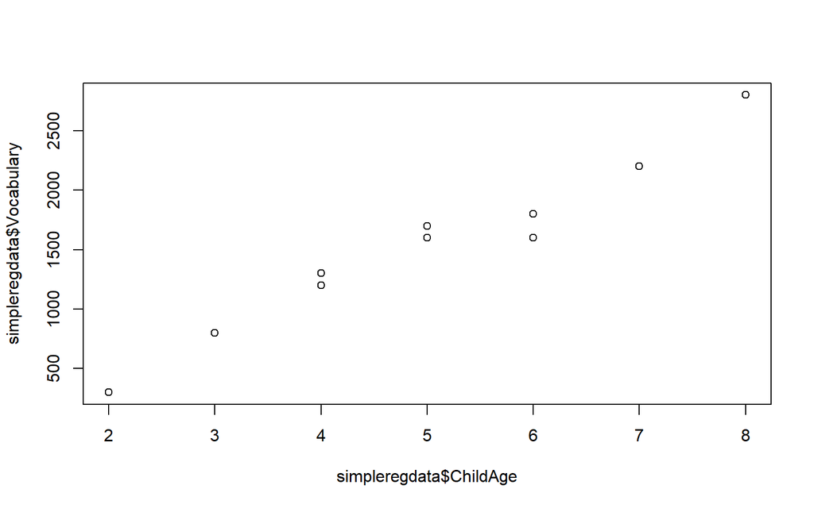

```r
plot(simpleregdata$ChildAge, simpleregdata$Vocabulary)
```

Without further ado, let’s run a simple regression, where we regress vocabulary (dependent variable) on age (predictor)

```r
options(scipen = 999)
fit <- lm(Vocabulary ~ ChildAge, data=simpleregdata)
summary(fit)
```

```
##
## Call:
## lm(formula = Vocabulary ~ ChildAge, data = simpleregdata)
##
## Residuals:
##     Min      1Q  Median      3Q     Max
## -303.33  -96.67   30.00  125.00  170.00
##
## Coefficients:
##             Estimate Std. Error t value  Pr(>|t|)
## (Intercept)  -336.67     152.63  -2.206    0.0585 .
## ChildAge      373.33      28.84  12.943 0.0000012 ***
## ---
## Signif. codes:  0 '***' 0.001 '**' 0.01 '*' 0.05 '.' 0.1 ' ' 1
##
## Residual standard error: 158 on 8 degrees of freedom
## Multiple R-squared:  0.9544, Adjusted R-squared:  0.9487
## F-statistic: 167.5 on 1 and 8 DF,  p-value: 0.000001202
```

In the output above, we can see the estimates of the intercept (-336.67) and the beta coefficient associated with the `ChildAge` variable (373.33). We can also see the p-values (0.0585 and 0.0000012, respectively).

Let’s look at some other useful functions:

We can extract the model coefficients by using the `coefficients` command:

```r
coefficients(fit)
```

```
## (Intercept)    ChildAge
##   -336.6667    373.3333
```

We can also get confidence intervals for the coefficients. Here, we choose 95% confidence intervals, but we can choose any confidence level.

```r
confint(fit, level=0.95)
```

```
##                 2.5 %    97.5 %
## (Intercept) -688.6210  15.28762
## ChildAge     306.8202 439.84644
```

There is another way to obtain coefficients, and to extract other information from the regression summary, as shown below.

```r
summary(fit)$coefficients
```

```
##              Estimate Std. Error  t value       Pr(>|t|)
## (Intercept) -336.6667  152.62518 -2.20584 0.058459099286
## ChildAge     373.3333   28.84345 12.94344 0.000001201883
```

```r
tvals <- summary(fit)$coefficients[,3]  #3rd column in coefficients matrix
tvals
```

```
## (Intercept)    ChildAge
##    -2.20584    12.94344
```

```r
pvals <- summary(fit)$coefficients[,4]  #4th column in coefficients matrix
pvals
```

```
##    (Intercept)       ChildAge
## 0.058459099286 0.000001201883
```

Below are some important functions that we will be using regularly. They allow us to save the fitted - or predicted - values (y-hats), as well as residuals and standardized residuals, as columns in the data frame `simpleregdata`.

For instance, we are saving the predicted values as variable `predvals`, residuals as variable `resids`, and standardized residuals as variable `stdres` in the data frame `simpleregdata`.

```r
simpleregdata$predvals <- fitted(fit)
simpleregdata$resids <- residuals(fit)
simpleregdata$stdres <- rstandard(fit)
```

Now, let’s look at the first few rows of the data frame `simpleregdata` and we will see that these variables are in there.

```r
head(simpleregdata)
```

```
##   Person.. ChildAge Vocabulary  predvals     resids     stdres
## 1        1        8       2800 2650.0000  150.00000  1.2257668
## 2        2        3        800  783.3333   16.66667  0.1204863
## 3        3        4       1200 1156.6667   43.33333  0.2946377
## 4        4        5       1700 1530.0000  170.00000  1.1342790
## 5        5        6       1600 1903.3333 -303.33333 -2.0624636
## 6        6        6       1800 1903.3333 -103.33333 -0.7025975
```

We can also look at the histogram of the residuals by using the `hist` command:

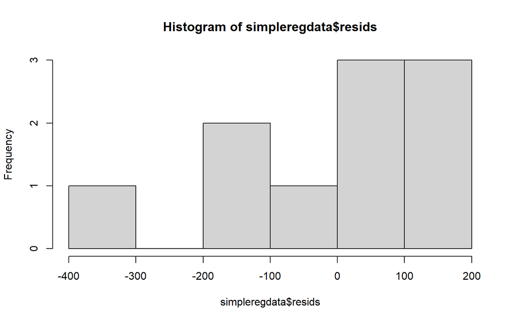

```r
hist(simpleregdata$resids)
```

Now that we have residuals and predicted values saved as variables in the data frame, we can go ahead and calculate the sum of squared errors (SSE), total sum of squares (SST), and regression sum of squares (SSR) manually below.

```r
SSE <- sum(simpleregdata$resids^2)
                #(y                  - y-bar)^2
SST <- sum((simpleregdata$Vocabulary-mean(simpleregdata$Vocabulary))^2)
SSR <- SST - SSE
```

From this, we can also calculate the R-square (which appears in the regression output above)

```r
R.Square <- SSR/SST
```

Now, let’s print the variance table that contains SSE, SSR, SST and the R-square.

```r
Variance.Table <-cbind(SSE, SSR, SST, R.Square)
Variance.Table
```

```
##           SSE     SSR     SST  R.Square
## [1,] 199666.7 4181333 4381000 0.9544244
```

Luckily, we don’t have to do this manually, as we can request that `R` print out the ANOVA (Analysis of Variance) table containing this output. You will see that SSE and SSR will be in the `anova(fit)` output, but SST is not. However, we can simply calculate SST by summing SSE and SSR.

```r
anova(fit)
```

```
## Analysis of Variance Table
##
## Response: Vocabulary
##           Df  Sum Sq Mean Sq F value      Pr(>F)
## ChildAge   1 4181333 4181333  167.53 0.000001202 ***
## Residuals  8  199667   24958
## ---
## Signif. codes:  0 '***' 0.001 '**' 0.01 '*' 0.05 '.' 0.1 ' ' 1
```

```r
SST <- 4181333 + 199667
SST
```

```
## [1] 4381000
```

One thing we may want to do is check whether there is a problem with heteroskedasticity. To do this, we can create a standardized residual-by-predicted plot and see if the variance of residuals is different for different values of y-hats (`predvals`).

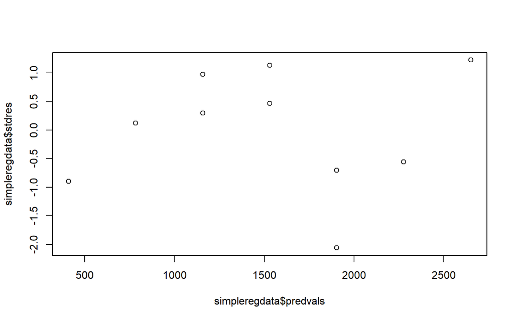

```r
plot(simpleregdata$predvals, simpleregdata$stdres)
```

## Multiple Regression with Continuous and Categorical Predictors

For multiple regression, we will be using the data set `multregdata` that contains 1720 observations corresponding to the 1720 residential block groups in the year 2000 in the City of Philadelphia. The data set contains several variables obtained from the US Census, including median house value (`MEDHVAL`), median household income (`MEDHHINC`), number of people living in poverty (`NBELPOV100`), percent of individuals with at least a bachelor’s degree (`PCTBACHMOR`), percent of housing units that are detached (`PCTSINGLE`), and percent of housing units that are vacant (`PCTVACANT`). In addition, I created a variable called `Police.Unit`, which is essentially a random assignment of each block group to a community policing unit. This is explained in more detail in the slides. Below, we import the data and look at the first few rows.

```r
setwd("C:\\Users\\eugeneby\\Dropbox\\Documents\\Work and School\\Teaching\\CPLN 671 - Statistics and Data Mining\\2023_MUSA_5000_GitHub\\Data\\Lecture 6 - R")
multregdata <- read.csv("RegressionData.csv")
head(multregdata)
```

```
##   POLY_ID      AREAKEY MEDHVAL PCTBACHMOR MEDHHINC PCTVACANT PCTSINGLES
## 1       1 421000000000  225000    64.4737    49107   13.2075    11.3208
## 2       2 421000000000  181900    78.7805    46304    0.0000     0.0000
## 3       3 421000000000  225000    45.0000    26875    0.0000    42.8571
## 4       4 421000000000  113600    64.3564    49375    7.7500     0.0000
## 5       5 421000000000  126200    13.0690     9432    9.7387     0.0000
## 6       6 421000000000   55000    32.6087     2499    0.0000     0.0000
##   NBELPOV100 Police.Unit
## 1          0           A
## 2         25           A
## 3         14           A
## 4         70           A
## 5        473           A
## 6        113           A
```

The first thing we want to do is to prepare our data for regression analysis. We may want to include the variable `Police.Unit` as a predictor. However, because it is a categorical variable, with values of A, B, C and D, we cannot enter it into the regression directly. Instead, as discussed in the slides, we want to create 4 binary (i.e., dummy) variables, and include 3 of them in the regression. The process for this is described at the link below: https://subscription.packtpub.com/book/big_data_and_business_intelligence/9781783989065/1/ch01lvl1sec21/creating-dummies-for-categorical-variables. Let’s create the dummies!

```r
multregdata$Police.A <- ifelse(multregdata$Police.Unit == 'A', 1, 0)
multregdata$Police.B <- ifelse(multregdata$Police.Unit == 'B', 1, 0)
multregdata$Police.C <- ifelse(multregdata$Police.Unit == 'C', 1, 0)
multregdata$Police.D <- ifelse(multregdata$Police.Unit == 'D', 1, 0)
head(multregdata)
```

```
##   POLY_ID      AREAKEY MEDHVAL PCTBACHMOR MEDHHINC PCTVACANT PCTSINGLES
## 1       1 421000000000  225000    64.4737    49107   13.2075    11.3208
## 2       2 421000000000  181900    78.7805    46304    0.0000     0.0000
## 3       3 421000000000  225000    45.0000    26875    0.0000    42.8571
## 4       4 421000000000  113600    64.3564    49375    7.7500     0.0000
## 5       5 421000000000  126200    13.0690     9432    9.7387     0.0000
## 6       6 421000000000   55000    32.6087     2499    0.0000     0.0000
##   NBELPOV100 Police.Unit Police.A Police.B Police.C Police.D
## 1          0           A        1        0        0        0
## 2         25           A        1        0        0        0
## 3         14           A        1        0        0        0
## 4         70           A        1        0        0        0
## 5        473           A        1        0        0        0
## 6        113           A        1        0        0        0
```

From the output above, we can see that there are now 4 new variables in the data frame `multregdata`. They are `Police.A`, which takes on the value of 1 if the community policing unit in the block group is unit A, and the value of 0 otherwise; `Police.B`, which takes on the value of 1 if the community policing unit in the block group is unit B, and the value of 0 otherwise; `Police.C`, which takes on the value of 1 if the community policing unit in the block group is unit C, and the value of 0 otherwise; and `Police.D`, which takes on the value of 1 if the community policing unit in the block group is unit D, and the value of 0 otherwise. Again, we can include (at most) 3 of these in the regression, because including all 4 would result in issues with multicollinearity.

And now, let’s run some regressions. First, let’s run a simple regression where we regress median house value on median household income. We see that median household income is a very significant predictor of median house value, and explains 42.89% of variance in median house value.

```r
reg1 <- lm(MEDHVAL ~ MEDHHINC, data=multregdata)
summary(reg1)
```

```
##
## Call:
## lm(formula = MEDHVAL ~ MEDHHINC, data = multregdata)
##
## Residuals:
##     Min      1Q  Median      3Q     Max
## -157597  -20939   -6561    8110  557533
##
## Coefficients:
##                Estimate  Std. Error t value             Pr(>|t|)
## (Intercept) -9767.35710  2383.03943  -4.099            0.0000435 ***
## MEDHHINC        2.41125     0.06712  35.922 < 0.0000000000000002 ***
## ---
## Signif. codes:  0 '***' 0.001 '**' 0.01 '*' 0.05 '.' 0.1 ' ' 1
##
## Residual standard error: 45360 on 1718 degrees of freedom
## Multiple R-squared:  0.4289, Adjusted R-squared:  0.4286
## F-statistic:  1290 on 1 and 1718 DF,  p-value: < 0.00000000000000022
```

Now, let’s include percent of single housing units as an additional predictor. We see that it is a significant predictor, though the R-square doesn’t go up by much.

```r
reg2 <- lm(MEDHVAL ~ MEDHHINC + PCTSINGLES, data=multregdata)
summary(reg2)
```

```
##
## Call:
## lm(formula = MEDHVAL ~ MEDHHINC + PCTSINGLES, data = multregdata)
##
## Residuals:
##     Min      1Q  Median      3Q     Max
## -150471  -20351   -7133    7064  560805
##
## Coefficients:
##                Estimate  Std. Error t value             Pr(>|t|)
## (Intercept) -9320.58451  2376.23989  -3.922            0.0000911 ***
## MEDHHINC        2.29514     0.07329  31.315 < 0.0000000000000002 ***
## PCTSINGLES    348.52374    90.15921   3.866             0.000115 ***
## ---
## Signif. codes:  0 '***' 0.001 '**' 0.01 '*' 0.05 '.' 0.1 ' ' 1
##
## Residual standard error: 45180 on 1717 degrees of freedom
## Multiple R-squared:  0.4339, Adjusted R-squared:  0.4332
## F-statistic: 657.9 on 2 and 1717 DF,  p-value: < 0.00000000000000022
```

Now, let’s include 3 police unit dummies (`Police.A`, `Police.B`, and `Police.C`). Here, `Police.D` is the reference category and is not included in the regression. We can see that block groups covered by community policing unit A have significantly higher median house value than block groups covered by community policing unit D. This difference in median house value is on average $24,314 (holding other predictors constant). Similarly, block groups covered by policing unit B have significantly higher median house value than block groups covered by community policing unit D. This difference in median house value is on average $7,604. However, the median house value isn’t significantly different for block groups covered by policing units C and D (p=0.0941).

```r
reg3 <- lm(MEDHVAL ~ MEDHHINC + PCTSINGLES + Police.A + Police.B + Police.C, data=multregdata)
summary(reg3)
```

```
##
## Call:
## lm(formula = MEDHVAL ~ MEDHHINC + PCTSINGLES + Police.A + Police.B +
##     Police.C, data = multregdata)
##
## Residuals:
##     Min      1Q  Median      3Q     Max
## -151087  -19871   -5802    9575  563417
##
## Coefficients:
##                 Estimate   Std. Error t value             Pr(>|t|)
## (Intercept) -21700.56279   3268.94357  -6.638  0.00000000004242344 ***
## MEDHHINC         2.36268      0.07477  31.597 < 0.0000000000000002 ***
## PCTSINGLES     442.58670     89.14870   4.965  0.00000075692043696 ***
## Police.A     24314.60002   3012.10526   8.072  0.00000000000000129 ***
## Police.B      7604.28718   3152.47705   2.412               0.0160 *
## Police.C      5047.44449   3013.26734   1.675               0.0941 .
## ---
## Signif. codes:  0 '***' 0.001 '**' 0.01 '*' 0.05 '.' 0.1 ' ' 1
##
## Residual standard error: 44280 on 1714 degrees of freedom
## Multiple R-squared:  0.4569, Adjusted R-squared:  0.4554
## F-statistic: 288.4 on 5 and 1714 DF,  p-value: < 0.00000000000000022
```

What if we made community policing unit C (`Police.C`) the reference category instead? We see that block groups covered by policing unit A have significantly higher median house values than those covered by policing unit C (difference of $19,267 on average). However, median house values in block groups covered by unit B aren’t significantly different from those covered by unit C, and median house values in block groups covered by unit D aren’t significantly different from those covered by unit C (as we also saw in the previous regression).

```r
reg4 <- lm(MEDHVAL ~ MEDHHINC + PCTSINGLES + Police.A + Police.B + Police.D, data=multregdata)
summary(reg4)
```

```
##
## Call:
## lm(formula = MEDHVAL ~ MEDHHINC + PCTSINGLES + Police.A + Police.B +
##     Police.D, data = multregdata)
##
## Residuals:
##     Min      1Q  Median      3Q     Max
## -151087  -19871   -5802    9575  563417
##
## Coefficients:
##                 Estimate   Std. Error t value             Pr(>|t|)
## (Intercept) -16653.11831   3353.97608  -4.965       0.000000754628 ***
## MEDHHINC         2.36268      0.07477  31.597 < 0.0000000000000002 ***
## PCTSINGLES     442.58670     89.14870   4.965       0.000000756920 ***
## Police.A     19267.15553   3089.50262   6.236       0.000000000563 ***
## Police.B      2556.84270   3224.99569   0.793               0.4280
## Police.D     -5047.44449   3013.26734  -1.675               0.0941 .
## ---
## Signif. codes:  0 '***' 0.001 '**' 0.01 '*' 0.05 '.' 0.1 ' ' 1
##
## Residual standard error: 44280 on 1714 degrees of freedom
## Multiple R-squared:  0.4569, Adjusted R-squared:  0.4554
## F-statistic: 288.4 on 5 and 1714 DF,  p-value: < 0.00000000000000022
```

## Additional Multiple Regression Examples

In the examples above, we went immediately to regressions, which obviously isn’t the way to go. First, we need to look at distributions of variables, relationships between variables, and so on. Imagine a situation where we want to regress median household income on median house value, percentage of individuals with at least a bachelor’s degree, and vacancy rate. We would first do some exploratory analyses - perhaps examine the means and standard deviations and histograms.

```r
summary(multregdata)
```

```
##     POLY_ID          AREAKEY                MEDHVAL          PCTBACHMOR
##  Min.   :   1.0   Min.   :421000000000   Min.   :  10000   Min.   : 0.000
##  1st Qu.: 430.8   1st Qu.:421000000000   1st Qu.:  35075   1st Qu.: 4.847
##  Median : 860.5   Median :421000000000   Median :  53250   Median :10.000
##  Mean   : 860.5   Mean   :421000000000   Mean   :  66288   Mean   :16.081
##  3rd Qu.:1290.2   3rd Qu.:421000000000   3rd Qu.:  78625   3rd Qu.:20.074
##  Max.   :1720.0   Max.   :421000000000   Max.   :1000001   Max.   :92.987
##     MEDHHINC        PCTVACANT        PCTSINGLES        NBELPOV100
##  Min.   :  2499   Min.   : 0.000   Min.   :  0.000   Min.   :   0.0
##  1st Qu.: 21061   1st Qu.: 4.372   1st Qu.:  2.110   1st Qu.:  72.0
##  Median : 29719   Median : 9.091   Median :  5.714   Median : 147.0
##  Mean   : 31542   Mean   :11.289   Mean   :  9.226   Mean   : 189.8
##  3rd Qu.: 38750   3rd Qu.:16.282   3rd Qu.: 11.056   3rd Qu.: 257.0
##  Max.   :200001   Max.   :77.119   Max.   :100.000   Max.   :1267.0
##  Police.Unit           Police.A         Police.B         Police.C
##  Length:1720        Min.   :0.0000   Min.   :0.0000   Min.   :0.0000
##  Class :character   1st Qu.:0.0000   1st Qu.:0.0000   1st Qu.:0.0000
##  Mode  :character   Median :0.0000   Median :0.0000   Median :0.0000
##                     Mean   :0.2628   Mean   :0.2337   Mean   :0.2407
##                     3rd Qu.:1.0000   3rd Qu.:0.0000   3rd Qu.:0.0000
##                     Max.   :1.0000   Max.   :1.0000   Max.   :1.0000
##     Police.D
##  Min.   :0.0000
##  1st Qu.:0.0000
##  Median :0.0000
##  Mean   :0.2628
##  3rd Qu.:1.0000
##  Max.   :1.0000
```

Now, let’s look at the histograms of the variables. Here, breaks=50 tells us that we want 50 bins. We can see that none of the variables is normal - all look pretty skewed. Here, a logarithmic transformation may help normalize some of the variables, but we will skip this step here.

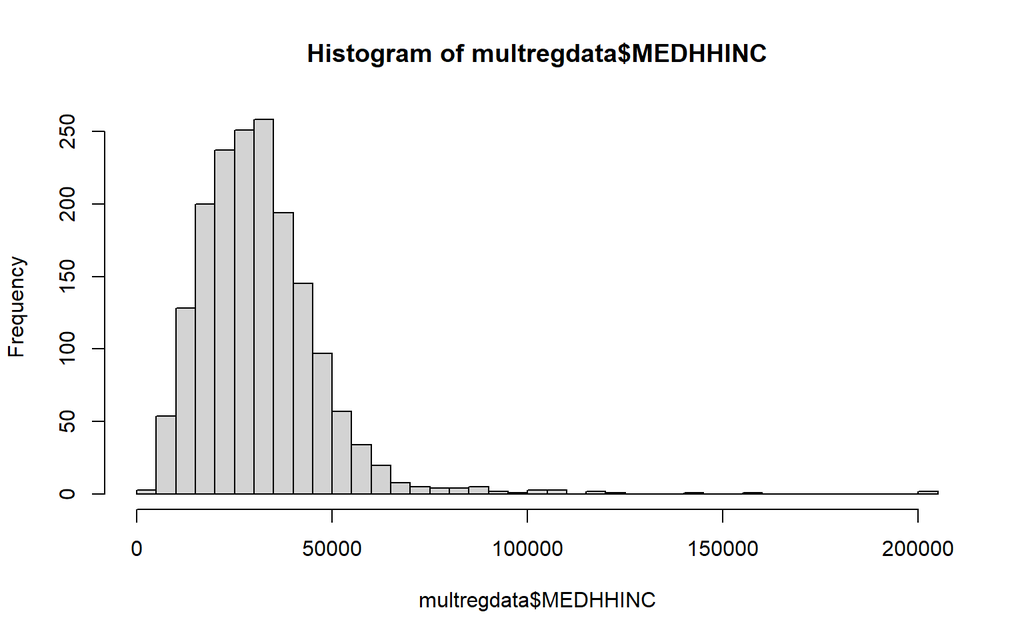

```r
hist(multregdata$MEDHHINC, breaks=50)
```

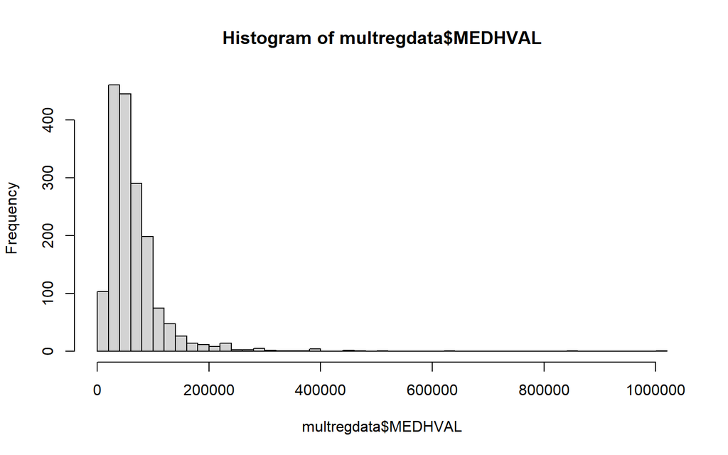

```r
hist(multregdata$MEDHVAL, breaks=50)
```

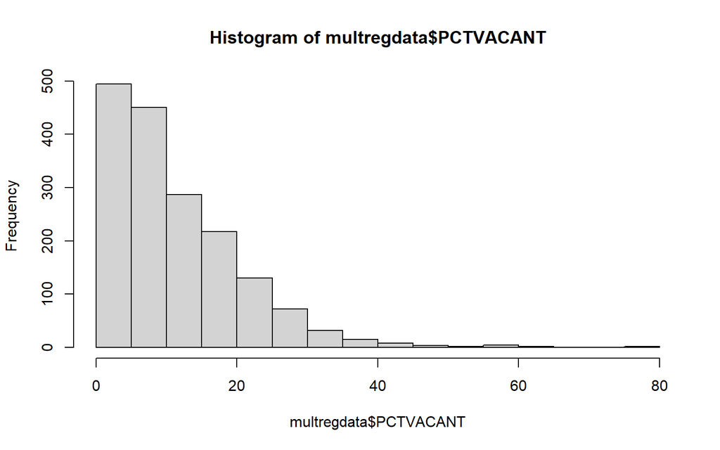

```r
hist(multregdata$PCTVACANT)
```

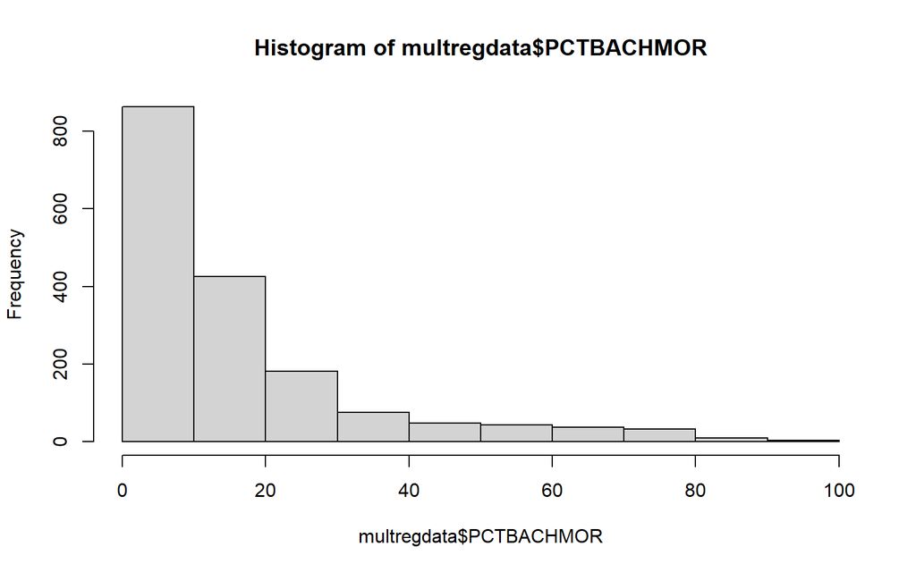

```r
hist(multregdata$PCTBACHMOR)
```

Now, let’s plot the dependent variable (`MEDHHINC`) against the three predictors to see whether a line does a good job with summarizing their relationship. From the plots below, it seems that it doesn’t.

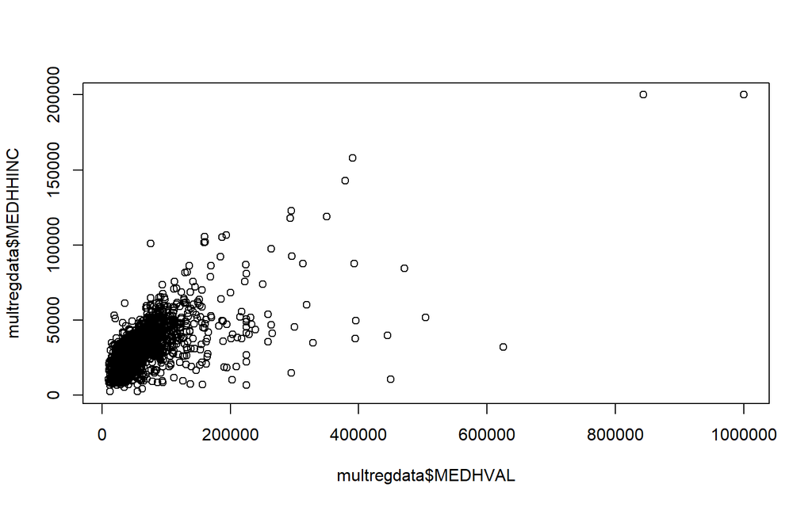

```r
plot(multregdata$MEDHVAL, multregdata$MEDHHINC)
```

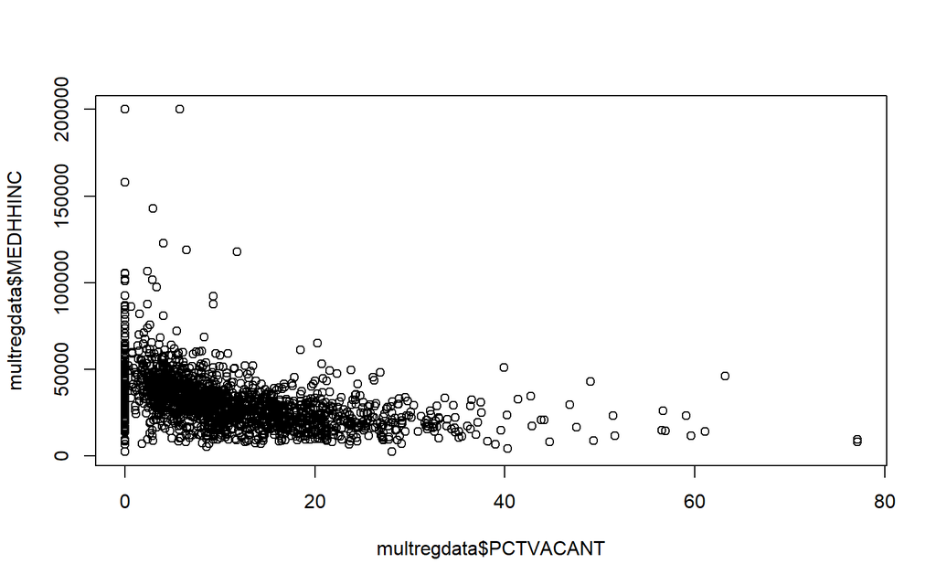

```r
plot(multregdata$PCTVACANT, multregdata$MEDHHINC)
```

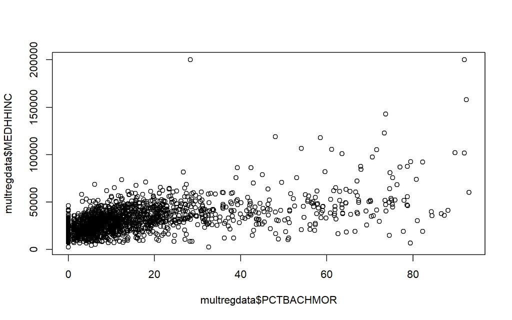

```r
plot(multregdata$PCTBACHMOR, multregdata$MEDHHINC)
```

Now, let’s look at the correlations between predictors. Recall that one of the assumptions of regression is no severe multicollinearity, so if the predictors are strongly intercorrelated (e.g., correlation coefficient is greater than |0.8|) then we would need to drop some of the predictors. Here, no pair of the predictors has a correlation that high. Here, we will use the `cor` function, and also use the `pairs` function that shows correlations, scatter plots and histograms all at once, which avoids the need to use the `hist` and `plot` commands above.

```r
#Selecting the relevant variables to be in the data frame predictors
predictors <- multregdata %>%
  select(MEDHVAL, PCTVACANT, PCTBACHMOR)
cor(predictors)
```

```
##               MEDHVAL  PCTVACANT PCTBACHMOR
## MEDHVAL     1.0000000 -0.3266071  0.7031137
## PCTVACANT  -0.3266071  1.0000000 -0.2983580
## PCTBACHMOR  0.7031137 -0.2983580  1.0000000
```

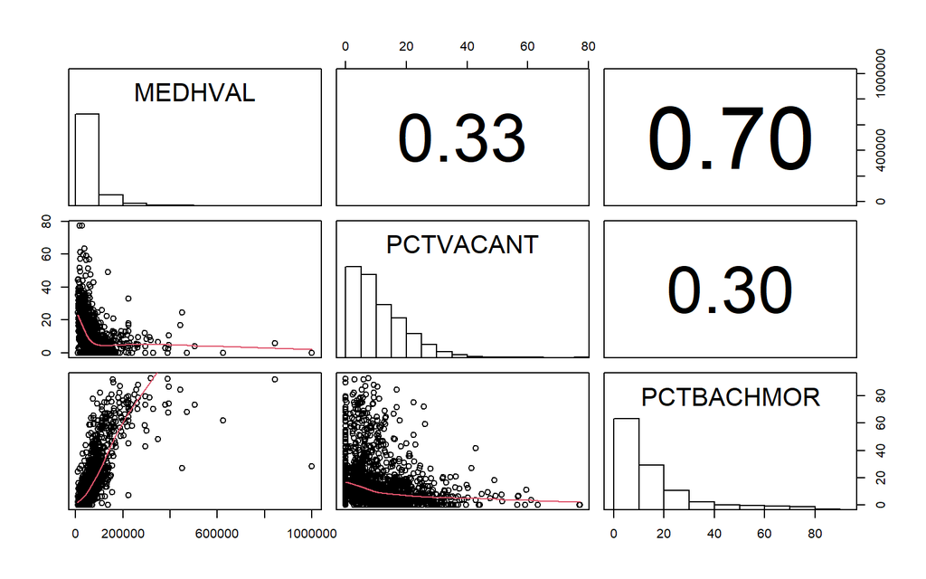

```r
#Setting up the function to show correlations such that higher correlations are in a larger font
panel.cor <- function(x, y, digits = 2, prefix = "", cex.cor, ...) {
  usr <- par("usr")
  on.exit(par(usr))
  par(usr = c(0, 1, 0, 1))
  r <- abs(cor(x, y, use = "complete.obs"))
  txt <- format(c(r, 0.123456789), digits = digits)[1]
  txt <- paste(prefix, txt, sep = "")
  if (missing(cex.cor)) cex.cor <- 0.8/strwidth(txt)
  text(0.5, 0.5, txt, cex =  cex.cor * (1 + r) / 2)
}

#Setting up the function to show histograms on the main diagonal
panel.hist <- function(x, ...) {
  usr <- par("usr")
  on.exit(par(usr))
  par(usr = c(usr[1:2], 0, 1.5) )
  h <- hist(x, plot = FALSE)
  breaks <- h$breaks
  nB <- length(breaks)
  y <- h$counts
  y <- y/max(y)
  rect(breaks[-nB], 0, breaks[-1], y, col = "white", ...)
}

#Here we go!
pairs(predictors,
  upper.panel = panel.cor,
  diag.panel  = panel.hist,
  lower.panel = panel.smooth
)
```

Below, we s run the regression, and from the output we can see that all three predictors are strongly significant.

```r
fit <- lm(MEDHHINC ~ MEDHVAL + PCTVACANT + PCTBACHMOR, data=multregdata)
summary(fit)
```

```
##
## Call:
## lm(formula = MEDHHINC ~ MEDHVAL + PCTVACANT + PCTBACHMOR, data = multregdata)
##
## Residuals:
##    Min     1Q Median     3Q    Max
## -82863  -5993   -185   5950  69792
##
## Coefficients:
##                 Estimate   Std. Error t value             Pr(>|t|)
## (Intercept) 25003.235067   627.836172  39.824 < 0.0000000000000002 ***
## MEDHVAL         0.130716     0.006699  19.514 < 0.0000000000000002 ***
## PCTVACANT    -376.207508    31.101789 -12.096 < 0.0000000000000002 ***
## PCTBACHMOR    131.860784    22.400341   5.887        0.00000000473 ***
## ---
## Signif. codes:  0 '***' 0.001 '**' 0.01 '*' 0.05 '.' 0.1 ' ' 1
##
## Residual standard error: 11670 on 1716 degrees of freedom
## Multiple R-squared:  0.4879, Adjusted R-squared:  0.487
## F-statistic:   545 on 3 and 1716 DF,  p-value: < 0.00000000000000022
```

Before, we looked at the correlation coefficients between predictors to assess multicollinearity. Now, let’s actually calculate the Variance Inflation Factors (VIFs). Recall that if the VIF is greater than 4 then there may be an issue with multicollinearity, and if it’s greater than 10, then there is severe multicollinearity. We don’t have any issues with multicollinearity here.

```r
vif(fit)        #Variance Inflation Factor (in the package car)
```

```
##    MEDHVAL  PCTVACANT PCTBACHMOR
##   2.038118   1.131236   1.998619
```

One diagnostic of interest that is often ignored is something called partial R-squared. These are partial correlations, squared, between predictor *i* and the dependent variable, y, with the influence of the other variables in the regression equation eliminated. The partial correlation coefficient squared is a measure of the extent to which that part of the variation in the dependent variablewhich is not explained by the other predictors is explained by predictor *i*. Because of this definition, the order in which predictors are entered into the model will not affect the value of the partial R-squared. (Source: http://www.unesco.org/webworld/portal/idams/html/english/E2regres.htm; For more information on partial R-squared, see: http://biol09.biol.umontreal.ca/borcardd/partialr2.pdf). Keep in mind that partial R-squares don’t have to add up to the total R-squared for the model because some of the variance in the dependent variable is explained by more than one predictor - this happens when the predictors are correlated and their common variance is also the variance that they share with the dependent variable.

Let’s calculate the partial R-squared values for each of our predictors:

```r
fit.glm <- glm(MEDHHINC ~ MEDHVAL + PCTVACANT + PCTBACHMOR, data=multregdata)
summary(fit.glm)
```

```
##
## Call:
## glm(formula = MEDHHINC ~ MEDHVAL + PCTVACANT + PCTBACHMOR, data = multregdata)
##
## Coefficients:
##                 Estimate   Std. Error t value             Pr(>|t|)
## (Intercept) 25003.235067   627.836172  39.824 < 0.0000000000000002 ***
## MEDHVAL         0.130716     0.006699  19.514 < 0.0000000000000002 ***
## PCTVACANT    -376.207508    31.101789 -12.096 < 0.0000000000000002 ***
## PCTBACHMOR    131.860784    22.400341   5.887        0.00000000473 ***
## ---
## Signif. codes:  0 '***' 0.001 '**' 0.01 '*' 0.05 '.' 0.1 ' ' 1
##
## (Dispersion parameter for gaussian family taken to be 136272526)
##
##     Null deviance: 456633347342  on 1719  degrees of freedom
## Residual deviance: 233843654149  on 1716  degrees of freedom
## AIC: 37103
##
## Number of Fisher Scoring iterations: 2
```

```r
rsq.partial(fit.glm)
```

```
## $adjustment
## [1] FALSE
##
## $variable
## [1] "MEDHVAL"    "PCTVACANT"  "PCTBACHMOR"
##
## $partial.rsq
## [1] 0.18160605 0.07856541 0.01979349
```

Now, let’s extract predicted values, residuals and standardized residuals from the last model, and save them as variables in the data frame `multregdata`.

```r
multregdata$predvals <- fitted(fit)
multregdata$resids <- residuals(fit)
multregdata$stdres <- rstandard(fit)
```

Let’s look at the histogram of standardized residuals. It looks pretty normal, depsite the fact that neither the dependent variable nor the predictors are normally distributed.

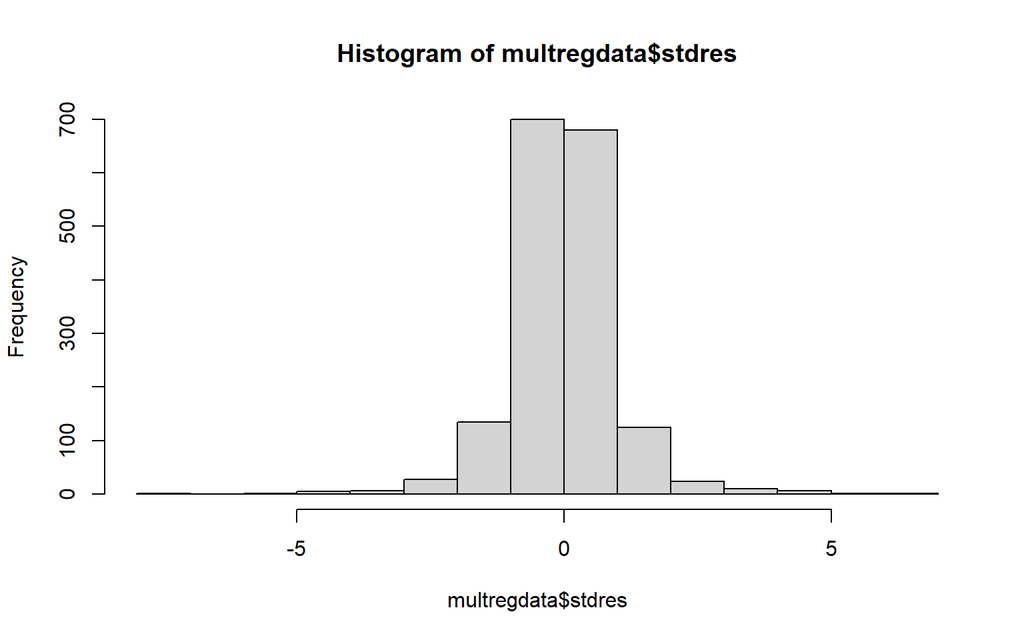

```r
hist(multregdata$stdres)
```

Now, let’s see whether we have issues with heteroscedasticity by looking at the standardized residual-by-predicted plot.

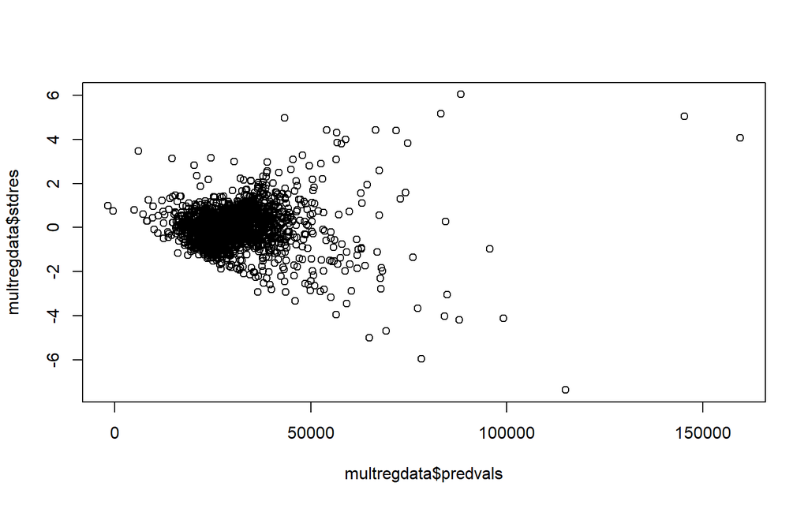

```r
plot(multregdata$predvals, multregdata$stdres)
```

Above, we have a textbook example of heteroscedasticity: the variance of residuals is small when y-hats (predicted values) are small, and large when y-hats are large. This is certainly problematic, so let’s look to see if we can identify the source of the problem by examining the scatter plots of standardized residuals by each predictor. All three predictors seem to contribute to heteroscedasticity, but visually, `MEDHVAL` is probably the most problematic.

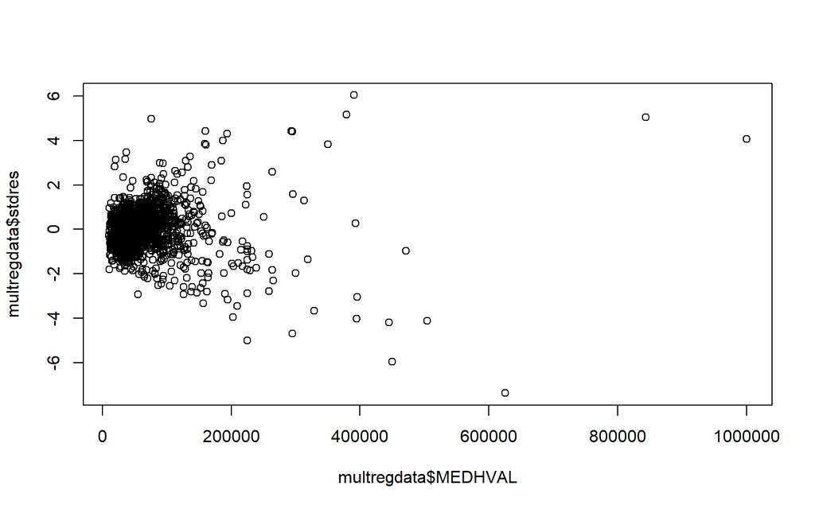

```r
plot(multregdata$MEDHVAL, multregdata$stdres)
```

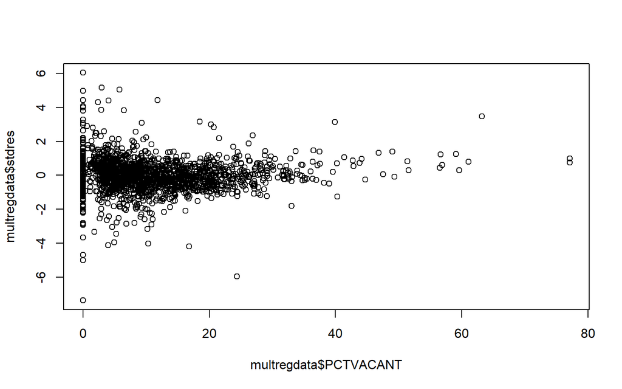

```r
plot(multregdata$PCTVACANT, multregdata$stdres)
```

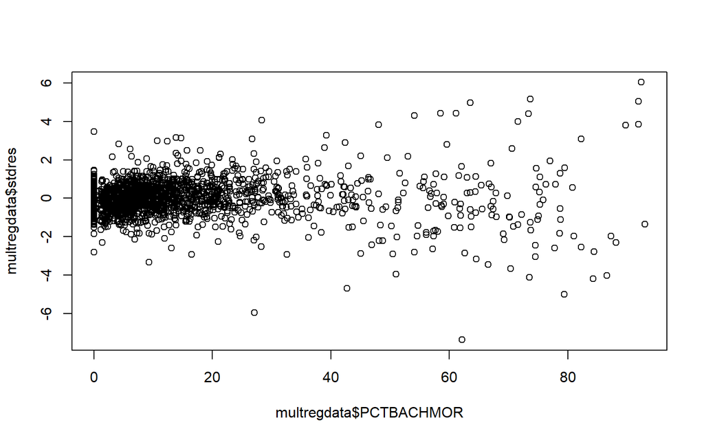

```r
plot(multregdata$PCTBACHMOR, multregdata$stdres)
```

Taking a log-transformation of a variable is often done for variables which are skewed (or when relationships between a predictor and the dependent variable is not linear, which is true in our case). The log-transformation is achieved with the code below. Re-running the regression with the log-transformed variables is an exercise left for the student.

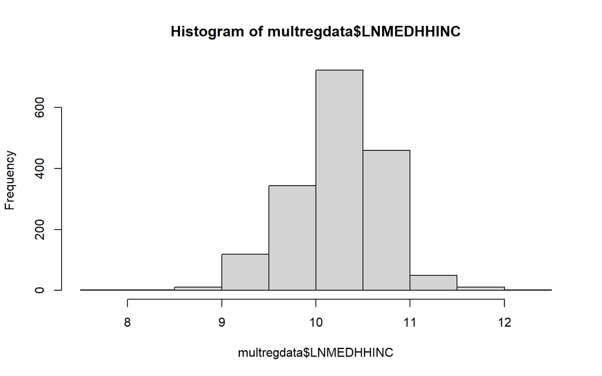

```r
multregdata$LNMEDHHINC = log(1+multregdata$MEDHHINC)
hist(multregdata$LNMEDHHINC)
```

## Cross-Validation

Imagine we have two models, model 1 and model 2, and we want to see which one does better on unseen data. This is where we can use cross-validation to compute the root mean squared error (RMSE) for the unseen data.

Here, in the first model, we have two predictors of `MEDHHINC`, which are `PCTVACANT` and `PCTSINGLES`. We run cross-validation with m=5 folds

```r
fit1 <- lm(MEDHHINC ~ PCTVACANT + PCTSINGLES, data=multregdata)
summary(fit1)
```

```
##
## Call:
## lm(formula = MEDHHINC ~ PCTVACANT + PCTSINGLES, data = multregdata)
##
## Residuals:
##    Min     1Q Median     3Q    Max
## -44717  -8370   -899   6435 144694
##
## Coefficients:
##             Estimate Std. Error t value            Pr(>|t|)
## (Intercept) 34569.73     584.24   59.17 <0.0000000000000002 ***
## PCTVACANT    -624.17      34.56  -18.06 <0.0000000000000002 ***
## PCTSINGLES    435.49      25.11   17.34 <0.0000000000000002 ***
## ---
## Signif. codes:  0 '***' 0.001 '**' 0.01 '*' 0.05 '.' 0.1 ' ' 1
##
## Residual standard error: 13640 on 1717 degrees of freedom
## Multiple R-squared:  0.3008, Adjusted R-squared:    0.3
## F-statistic: 369.4 on 2 and 1717 DF,  p-value: < 0.00000000000000022
```

```r
#In the output:
#Predicted (Predicted values using all observations)
#cvpred (cross-validation predictions)
#CV residual = y (in this case, MEDHHINC) - cvpred
```

```r
cv <- CVlm(data=multregdata, fit1, m=5)                     #m=5 sets it to 5 folds
```

```r
#Extracting MSEs
mse <- attr(cv, "ms")
rmse <- sqrt(mse)                         #Obtaining RMSE for model 1
rmse
```

```
## [1] 13676.84
```

In the second model, we have a different set of predictors, but (importantly) the same dependent variable. The RMSE is lower in the second model, so we can say that it’s better at predicting unseen data than the first model. Again, we use m=5 folds here.

```r
fit2 <- lm(MEDHHINC ~ PCTVACANT + MEDHVAL + PCTSINGLES, data=multregdata)
summary(fit2)
```

```
##
## Call:
## lm(formula = MEDHHINC ~ PCTVACANT + MEDHVAL + PCTSINGLES, data = multregdata)
##
## Residuals:
##    Min     1Q Median     3Q    Max
## -79410  -6488     -5   6052  63159
##
## Coefficients:
##                Estimate  Std. Error t value            Pr(>|t|)
## (Intercept) 24233.54076   614.80494   39.42 <0.0000000000000002 ***
## PCTVACANT    -378.28393    30.14582  -12.55 <0.0000000000000002 ***
## MEDHVAL         0.13953     0.00507   27.52 <0.0000000000000002 ***
## PCTSINGLES    252.45465    21.95479   11.50 <0.0000000000000002 ***
## ---
## Signif. codes:  0 '***' 0.001 '**' 0.01 '*' 0.05 '.' 0.1 ' ' 1
##
## Residual standard error: 11360 on 1716 degrees of freedom
## Multiple R-squared:  0.5149, Adjusted R-squared:  0.5141
## F-statistic: 607.2 on 3 and 1716 DF,  p-value: < 0.00000000000000022
```

```r
cv <- CVlm(data=multregdata, fit2, m=5)                     #m=5 sets it to 5 folds
```

```r
#summary(cv)
#Extracting MSEs
mse <- attr(cv, "ms")
rmse <- sqrt(mse)                                         #Obtaining RMSE for model 2
rmse
```

```
## [1] 11414.37
```

## Stepwise Regression

We can use stepwise regression to let the algorithm “automatically” select predictors for us. The code for doing so is below. We can see that in the final model, the variable `PCTVACANT` was dropped.

```r
fit <- lm(MEDHVAL~ PCTBACHMOR + PCTVACANT + MEDHHINC + PCTSINGLES,data=multregdata)
step <- stepAIC(fit, direction="both")
```

```
## Start:  AIC=36255.65
## MEDHVAL ~ PCTBACHMOR + PCTVACANT + MEDHHINC + PCTSINGLES
##
##              Df     Sum of Sq           RSS   AIC
## - PCTVACANT   1    2734047060 2443016078827 36256
## <none>                        2440282031768 36256
## - PCTSINGLES  1   45136222137 2485418253904 36285
## - MEDHHINC    1  381952301922 2822234333689 36504
## - PCTBACHMOR  1 1043809942181 3484091973949 36866
##
## Step:  AIC=36255.58
## MEDHVAL ~ PCTBACHMOR + MEDHHINC + PCTSINGLES
##
##              Df     Sum of Sq           RSS   AIC
## <none>                        2443016078827 36256
## + PCTVACANT   1    2734047060 2440282031768 36256
## - PCTSINGLES  1   44645952540 2487662031367 36285
## - MEDHHINC    1  445400169581 2888416248408 36542
## - PCTBACHMOR  1 1061214841090 3504230919917 36874
```

```r
step$anova
```

```
## Stepwise Model Path
## Analysis of Deviance Table
##
## Initial Model:
## MEDHVAL ~ PCTBACHMOR + PCTVACANT + MEDHHINC + PCTSINGLES
##
## Final Model:
## MEDHVAL ~ PCTBACHMOR + MEDHHINC + PCTSINGLES
##
##
##          Step Df   Deviance Resid. Df    Resid. Dev      AIC
## 1                                1715 2440282031768 36255.65
## 2 - PCTVACANT  1 2734047060      1716 2443016078827 36255.58
```